# Data Analysis of EPL 2019/20 Season - The Lockdown Games

## Decision Tree

Decision Tree works very well with multiple-class classification.

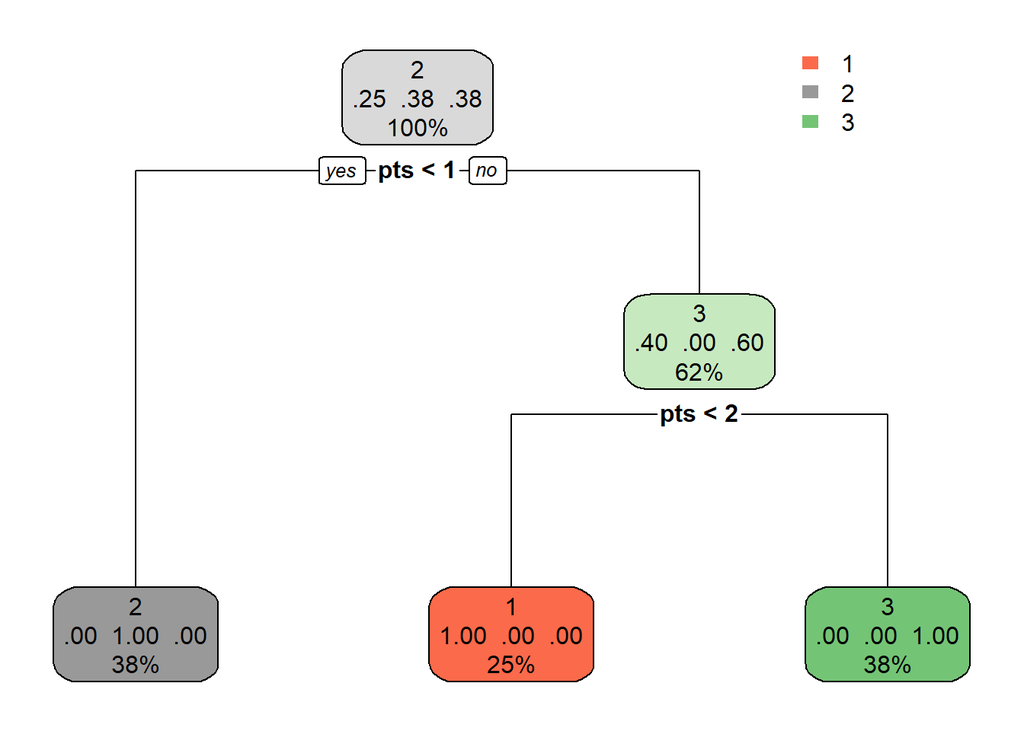

```r
set.seed(123) # to generate the same result every time.

#train test
train_indices <- sample(2,nrow(team),replace = T,prob = c(0.8,0.2))
train_data <- team[train_indices==1, ]
test_data <- team[-train_indices==2, ]

library(rpart)

#fitting model
DTmodel <- rpart(result ~ xG+ xGA+scored+conceded+xpts+deep+pts+ppda_cal+allowed_ppda,data = team,method = "class")

# Make predictions on the test set
predictions <- predict(DTmodel, newdata = test_data, type = "class")

library(rpart.plot)
rpart.plot(DTmodel)
```

## Neural Networks

Neural Network is inspired from human brain which is consists of input , hidden layer and output. It works well with multiple classification(www.datacamp.com, n.d.).

```r
library(neuralnet)
set.seed(123)

#train test
train_indices <- sample(1:nrow(team), 0.8 * nrow(team))
train_data <- team[train_indices, ]
test_data <- team[-train_indices, ]

nn_model <- neuralnet(result ~ xG+ xGA+scored+conceded+xpts+deep+pts+ppda_cal+allowed_ppda, data = train_data, hidden = c(2)) # 2 hidden layer

# Make predictions
nn_predictions <- predict(nn_model, newdata = test_data)

# Convert predictions to class labels
nn_predicted_classes <- ifelse(nn_predictions > 2, 3, 1)

# Evaluate the performance
conf_mat_nn <- table(nn_predicted_classes, test_data$result)

# Calculate accuracy, precision, recall, and F1 score
accuracy_nn <- sum(diag(conf_mat_nn)) / sum(conf_mat_nn)
precision_nn <- diag(conf_mat_nn) / rowSums(conf_mat_nn)
recall_nn <- diag(conf_mat_nn) / colSums(conf_mat_nn)
f1_nn <- 2 * (precision_nn * recall_nn) / (precision_nn + recall_nn)
# Print the results
print("\n")
```

```
## [1] "\n"
```

```r
cat("Neural Network Accuracy:", accuracy_nn, "\n")
```

```
## Neural Network Accuracy: 0.5344828
```

```r
cat("Neural Network Precision:", precision_nn, "\n")
```

```
## Neural Network Precision: 0.75 0.4027778
```

```r
cat("Neural Network Recall:", recall_nn, "\n")
```

```
## Neural Network Recall: 1 0.725 0.7674419
```

```r
cat("Neural Network F1 Score:", f1_nn, "\n")
```

```
## Neural Network F1 Score: 0.8571429 0.5178571 0.7586207
```

## Conclusion

From our models we cannot say that there is a connection between playing behind closed doors and team performance in football matches during the 2019/2020 season. This is not evident.Although we could comment in teams Performance in general which is classified on the basis of wins, losses, and draws. Further, data analysis shows us some interesting insights but not a confident showcase to say there is a relation.

## Learning Outcome

Overall the project was big enough to taste me in data analysis aspect.The whole design of the course (proposal,bidding,actual project) gave me a brief idea about working in industry level.The biggest challenges I find is how to tell a clean, simple story.Though I had sufficient domain knowledge.I think it will come with experience.If I had enough time I would like to dig in ‘player data’ and find some research content either on similar tone or new. Lastly, the question I like to raise or I would have been interested to explore is : ### How the player performance attributes to the team performance?

## References

www.premierleague.com. (n.d.). FPL basics: What is FPL? [online] Available at: https://www.premierleague.com/news/2173986.

www.datacamp.com. (n.d.). ANN (Artificial Neural Network) Models in R: Code & Examples on How to Build Your NN. [online] Available at: https://www.datacamp.com/tutorial/neural-network-models-r.